# Decision Trees and Random Forests on Forest Fires

## Random Forest

Random forests are a group of decision trees built from samples taken from the dataset. The prediction of the overall forest is the average of the predictions for each individual tree. I believe the main parameters we are able to tune are the number of trees that make up the forest and the number of random parameters to consider for each split.

### Creating random forest

```r
start1 <- Sys.time() # starting time
forest <- randomForest(formula=logArea ~ .-area, data=trainData)
end1 <- Sys.time() # Finishing time
(time1 <- end1 - start1) # total time
```

```
Time difference of 0.60291 secs
```

```r
forest
```

```
Call:
 randomForest(formula = logArea ~ . - area, data = trainData)
               Type of random forest: regression
                     Number of trees: 500
No. of variables tried at each split: 3

          Mean of squared residuals: 2.155572
                    % Var explained: -11.48
```

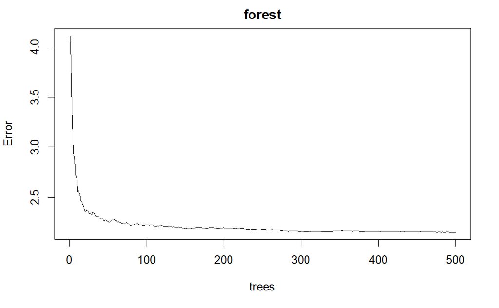

```r
plot(forest)
```

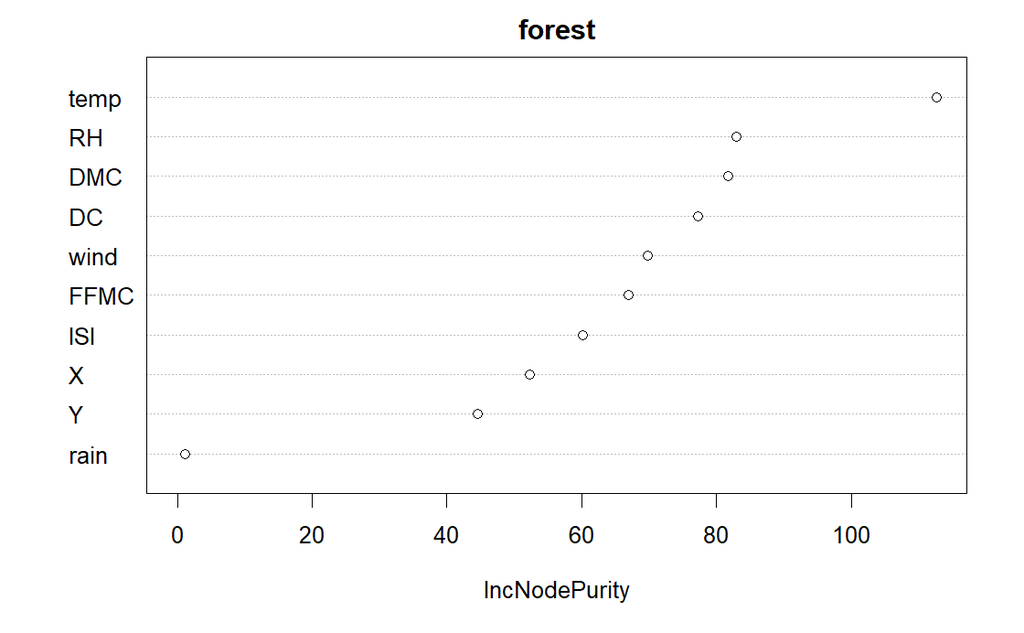

```r
varImpPlot(forest)
```

### Tune the Model

```
-0.7164317 0.01
0.5822979 0.01
0.3708489 0.01
0.06614896 0.01
```

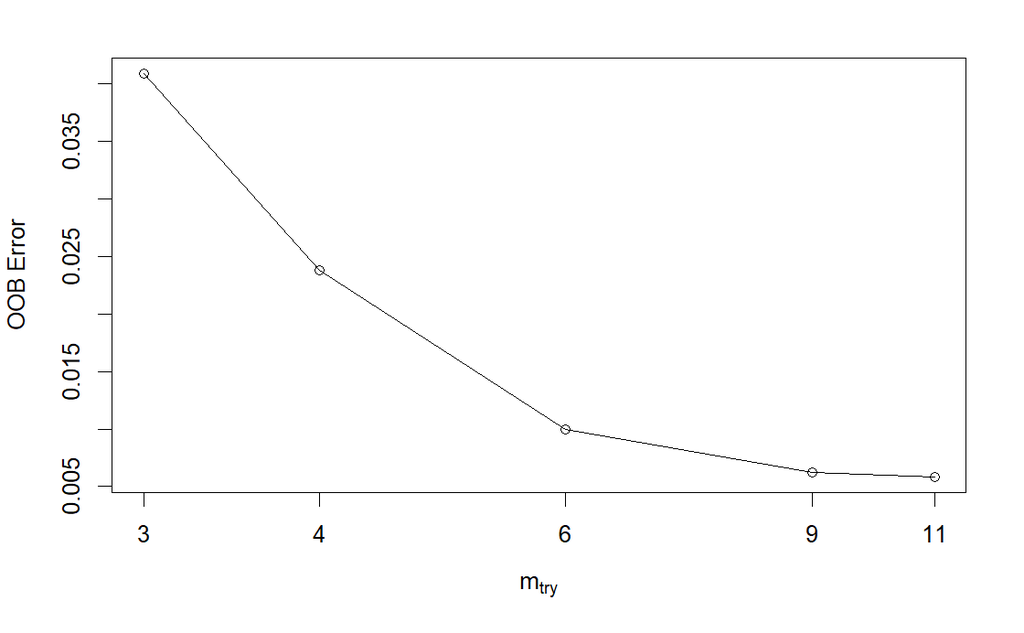

```r
start1 <- Sys.time() # starting time
moded_tuned <- tuneRF(
  x=trainData[,-2],
  y=trainData$logArea,
  ntreeTry=500,
  mtryStart = 4,
  stepFactor = 1.5,
  improve = 0.01,
  trace = FALSE
)
```

```r
end1 <- Sys.time() # Finishing time
(time1 <- end1 - start1) # total time
```

```
Time difference of 4.397903 secs
```

### Testing Tuned Model

```r
start1 <- Sys.time() # starting time
tuned_forest <- randomForest(formula=logArea ~ .-area, data=trainData, mtry=9)
end1 <- Sys.time() # Finishing time
(time1 <- end1 - start1) # total time
```

```
Time difference of 1.367212 secs
```

```r
forest_pred <- predict(forest, testData)
tforest_pred <- predict(tuned_forest, testData)
myRMSE(forest_pred, testData$logArea)
```

```
[1] 0.9532846
```

```r
myRMSE(tforest_pred, testData$logArea)
```

```
[1] 0.9330023
```

Time was a bit slower, around 1.3 seconds to train the new forest. Makes sense because there are more parameters to try splitting with. The tuned model is a bit better than the default model. Not sure if have 9 as mtry is too high and will cause repetition but it seems to work.

## Results

```r
myRMSE(prediction_model, testData$logArea)
```

```
[1] 1.327236
```

```r
myRMSE(y1, testData$logArea)
```

```
[1] 1.354739
```

```r
myRMSE(y2, testData$logArea)
```

```
[1] 1.359515
```

```r
myRMSE(forest_pred, testData$logArea)
```

```
[1] 0.9532846
```

```r
myRMSE(tforest_pred, testData$logArea)
```

```
[1] 0.9330023
```

In the end, the not pruned version of the decision tree was the best decision tree but the random forests had way lower RMSE values. The tuned random forest was the best model overall out of the two models we have tried.